# Hw08 - Categorical Predictors

Published

April 16, 2025

All of the questions below require you to use R and/or Stan to approximate the posterior distribution(s) of interest. I assume that you will do things like run multiple chains, calculate the Gelman-Rubin statistic, check the ACF of draws from the MCMC chain, determine the effective sample size, etc. However, I will only be looking at the posterior results. I recommend a warmup of 5,000 iterations and 5,000 saved values for each parameter using 4 chains.

**Hawks data**

Load the `Hawks` data set from the **Stat2Data** package. The data are a sample of 908 hawks from three different species. More details can be found by running `?Stat2Data::Hawks`. The variables in the data set include:

- `Species`: `CH`=Cooper’s, `RT`=Red-tailed, `SS`=Sharp-Shinned.
- `Wing`: length (mm) of primary wing feather from tip to wrist it attaches to.
- `Weight`: body weight (g).

Run the following commands to load this data set and remove any `NA` values.

```r
data(Hawks, package = "Stat2Data")
Hawks <- na.omit(Hawks[,c("Species", "Wing", "Weight")])
```

We will fit four different regression models to the data using `Wing` as the response variable and the other variables as explanatory variables.

*Data distribution*

$y_i \mid \mu_i, \sigma^2 \stackrel{indep.}{\sim} N(\mu_i, \sigma^2)$ for $i=1,2,\ldots,n$, where $\mu_i$ is based on the appropriate regression model (like in class).

*Prior distributions*

$\sigma^2 \sim$ Inv-Gamma(0.01, 0.01).

The regression coefficients are assumed to be independent and have a $N(0,100^2)$ prior distribution.

*Models*

Model 1: A one-way ANOVA using `Species` as the categorical predictor and “CH” as the reference level.

Model 2: A simple linear regression model using `Weight` as the only predictor.

Model 3: A parallel lines (main effects) model using `Weight` as the quantitative predictor and `Species` as the categorical predictor with “CH” as the reference level.

Model 4: A separate lines (interaction) model using `Weight` as the quantitative predictor and `Species` as the categorical predictor with “CH” as the reference level.

# Helper Functions

**Function to run and fit the model**

```r
run_or_load_stan_model <- function(model_code, data, model_name, iter = 10000, chains = 4, verbose = TRUE) {
  rda_file <- paste0(model_name, ".rda")

  if (!file.exists(rda_file)) {
    if (verbose) message("Compiling model: ", model_name)

    fit <- stan(model_code = model_code, data = data, iter = iter, chains = chains)
    mod <- stan_model(model_code = model_code)

    # This assign functions allows me to create variables in the global environment
    # During this process which is just kinda convenient
    assign(model_name, mod, envir = .GlobalEnv)
    save(list = model_name, file = rda_file, compress = "xz")
  } else {
    if (verbose) message("Loading pre-compiled model: ", model_name)

    load(rda_file, envir = .GlobalEnv)
    mod <- get(model_name, envir = .GlobalEnv)
    fit <- sampling(mod, data = data, iter = iter, chains = chains)
  }

  return(fit)
}
```

# Problem 1

Create a scatter plot of the data using `Wing` as the y variable, `Weight` as the x variable, and distinguishing between the `species` using appropriate symbols/colors. Include the appropriate legend. Do you notice a relationship between the three variables?

**Solution**

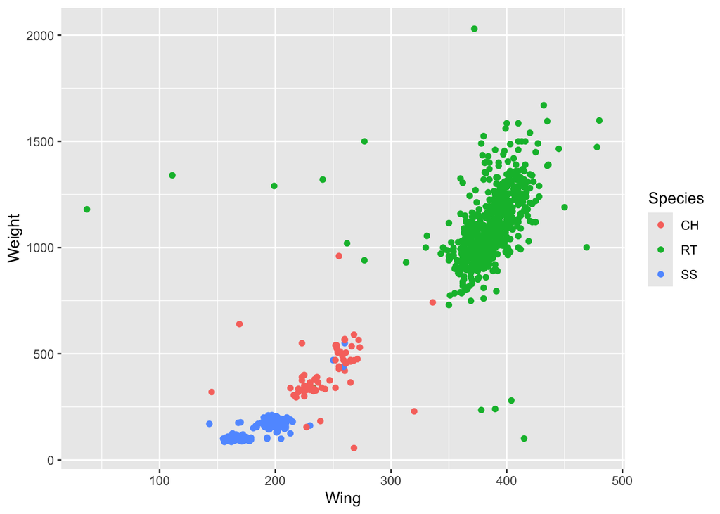

```r
Hawks %>%
    ggplot(aes(x=Wing, y=Weight, color=Species)) +
    geom_point()
```

RT hawks appear to be the heaviest on average, with CH falling behind in 2nd and SS hawks being the lightest. Each species also seems to have its own mostly distinct cluster. There isn’t a lot of overlap between the species.

# Problem 2

Fit a one-way ANOVA model (Model 1) using Stan. In a simple, tabular format, provide the posterior mean, the 0.025 quantile, and the 0.975 quantile for all regression coefficients and the variance $\sigma^2$.

**Solution**

**Modeling**

```r
stanmod <- "
data {
  int<lower=1> n; // number of observations
  vector[n] y; // data
  vector[n] rt; //indicator for red tail
  vector[n] ss; //indicator for sharp shinned
  real<lower=0> v; // sample variance of y
}
parameters {
  real<lower=0> sigmasq;
  real mu0;
  real alpha2;
  real alpha3;
}
transformed parameters{
  vector[n] mu;   // mean of data distribution
  mu = mu0 + alpha2*rt + alpha3*ss;
}
model {
  //specify priors
  mu0 ~ normal(0.0, 100);
  alpha2 ~ normal(0.0, 100);
  alpha3 ~ normal(0.0, 100);
  sigmasq ~ inv_gamma(0.01, 0.01);

  // data distribution
  for(i in 1:n){
    y[i] ~ normal(mu[i], sqrt(sigmasq));
  }
}
generated quantities {
  real Rbsq;          // goodness-of-fit
  vector[n] log_lik;  // log likelihood of data
  Rbsq = 1 - sigmasq/v;
  for (i in 1:n) log_lik[i] = normal_lpdf(y[i]|mu[i], sqrt(sigmasq));
}
"

v <- var(Hawks$Wing)
rt <- (Hawks$Species == "RT") + 0
ss <- (Hawks$Species == "SS") + 0

stan_dat <- list(
    n = nrow(Hawks),
    y = Hawks$Wing,
    rt = rt,
    ss = ss,
    v = v
)

model1_fit <- run_or_load_stan_model(
    model_code = stanmod,
    data = stan_dat,
    model_name = "hawks_model1"
)
```

```
Loading pre-compiled model: hawks_model1
```

| Statistic | Mean | SD | 0.025 | 0.975 |
| --- | --- | --- | --- | --- |
| $\sigma^2$ | 844.24 | 40.43 | 768.85 | 926.63 |
| $\mu_0$ | 244.01 | 3.56 | 237.08 | 251.01 |
| $\alpha_2$ | 139.55 | 3.75 | 132.24 | 146.92 |
| $\alpha_3$ | -59.14 | 4.00 | -66.93 | -51.26 |

# Problem 3

Provide a point estimate (using the posterior means) of the regression equation for the one-way ANOVA model (Model 1). Interpret each coefficient in the context of the problem.

**Solution**

$$\begin{align}
\mu_i &= 244.01 + 139.55\alpha_2 - 59.13\alpha_3 \\
\mu_1 &= 244.01 \\
\mu_2 &= 383.56 \\
\mu_3 &= 184.88
\end{align}$$

# Problem 4

Fit a simple linear regression model (Model 2) using Stan. In a simple, tabular format, provide the posterior mean, the 0.025 quantile, and the 0.975 quantile for all regression coefficients and the variance $\sigma^2$.

**Solution**

**Modeling**

```r
stanmod <- "
data {
  int<lower=1> n; // number of observations
  vector[n] y; // data
  vector[n] weight;
  real<lower=0> v; // sample variance of y
}
parameters {
  real<lower=0> sigmasq;
  real beta0;
  real beta1;
}
transformed parameters{
  vector[n] mu;   // mean of data distribution
  mu = beta0 + beta1*weight;
}
model {
  //specify priors
  beta0 ~ normal(0.0, 100);
  beta1 ~ normal(0.0, 100);
  sigmasq ~ inv_gamma(0.01, 0.01);

  // data distribution
  for(i in 1:n){
    y[i] ~ normal(mu[i], sqrt(sigmasq));
  }
}
generated quantities {
  real Rbsq;          // goodness-of-fit
  vector[n] log_lik;  // log likelihood of data
  Rbsq = 1 - sigmasq/v;
  for (i in 1:n) log_lik[i] = normal_lpdf(y[i]|mu[i], sqrt(sigmasq));
}
"

stan_dat <- list(
    n = nrow(Hawks),
    y = Hawks$Wing,
    weight = Hawks$Weight,
    v=v
)

model2_fit <- run_or_load_stan_model(
    model_code = stanmod,
    data = stan_dat,
    model_name = "hawks_model2"
)
```

```
Loading pre-compiled model: hawks_model2
```

| Statistic | Mean | SD | 0.025 | 0.975 |
| --- | --- | --- | --- | --- |
| $\sigma^2$ | 1146.64 | 54.71 | 1045.44 | 1258.14 |
| $\beta_0$ | 167.34 | 2.21 | 163.06 | 171.66 |
| $\beta_1$ | 0.19 | 0.002 | 0.19 | 0.20 |

# Problem 5

Provide a point estimate (using the posterior means) of the regression equation for the simple linear regression model (Model 2). Interpret each coefficient in the context of the problem.

**Solution**

$$\hat{y} = 167.34 + 0.19\text{weight}$$

# Problem 6

Fit a parallel lines regression model (Model 3) using Stan. In a simple, tabular format, provide the posterior mean, the 0.025 quantile, and the 0.975 quantile for all regression coefficients and the variance $\sigma^2$.

**Solution**

**Modeling**

```r
stanmod <- "
data {
  int<lower=1> n; // number of observations
  vector[n] y; // data
  vector[n] weight;
  vector[n] rt; //indicator for red tail
  vector[n] ss; //indicator for sharp shinned
  real<lower=0> v; // sample variance of y
}
parameters {
  real<lower=0> sigmasq;
  real beta0;
  real beta1;
  real alpha2;
  real alpha3;
}
transformed parameters{
  vector[n] mu;   // mean of data distribution
  mu = beta0 + beta1*weight + alpha2*rt + alpha3*ss;
}
model {

  //specify priors
  beta0 ~ normal(0.0, 100);
  beta1 ~ normal(0.0, 100);
  alpha2 ~ normal(0.0, 100);
  alpha3 ~ normal(0.0, 100);
  sigmasq ~ inv_gamma(0.01, 0.01);

  // data distribution
  for(i in 1:n){
    y[i] ~ normal(mu[i], sqrt(sigmasq));
  }
}
generated quantities {
  real Rbsq;          // goodness-of-fit
  vector[n] log_lik;  // log likelihood of data
  Rbsq = 1 - sigmasq/v;
  for (i in 1:n) log_lik[i] = normal_lpdf(y[i]|mu[i], sqrt(sigmasq));
}
"

stan_dat <- list(
    n = nrow(Hawks),
    y = Hawks$Wing,
    weight = Hawks$Weight,
    rt = rt,
    ss = ss,
    v=v
)

model3_fit <- run_or_load_stan_model(
    model_code = stanmod,
    data = stan_dat,
    model_name = "hawks_model3"
)
```

```
Loading pre-compiled model: hawks_model3
```

| Statistic | Mean | SD | 0.025 | 0.975 |
| --- | --- | --- | --- | --- |
| $\sigma^2$ | 705.9 | 33.18 | 644.5 | 773.3 |
| $\beta_0$ | 213.5 | 3.972 | 205.6 | 221.2 |
| $\beta_1$ | 0.07271 | 0.005508 | 0.06192 | 0.08347 |
| $\alpha_2$ | 90.53 | 5.014 | 80.74 | 100.4 |
| $\alpha_3$ | -39.38 | 3.918 | -47.08 | -31.63 |

# Problem 7

Provide a point estimate (using the posterior means) of the regression equation for the parallel lines regression model (Model 3). Interpret each coefficient related to the `CH` and `RT` species in the context of the problem.

**Solution**

$$\begin{align}
\mu_i &= 213.5 + 0.07X_1 + 90.53\alpha_2 - 39.38\alpha_3 \\
\mu_1 &= 213.5 + 0.07X_1 \\
\mu_2 &= 304.03 + 0.07X_1 \\
\mu_3 &= 174.12 + 0.07X_1
\end{align}$$

# Problem 8

Fit a separate lines regression model (Model 4) using Stan. In a simple, tabular format, provide the posterior mean, the 0.025 quantile, and the 0.975 quantile for all regression coefficients and the variance $\sigma^2$.

**Solution**

**Modeling**

```r
stanmod <- "
data {
  int<lower=1> n; // number of observations
  vector[n] y; // data
  vector[n] weight;
  vector[n] rt; //indicator for red tail
  vector[n] ss; //indicator for sharp shinned
  real<lower=0> v; // sample variance of y
}
parameters {
  real<lower=0> sigmasq;
  real beta0;
  real beta1;
  real alpha2;
  real alpha3;
  real delta2;
  real delta3;
}
transformed parameters{
  vector[n] mu;   // mean of data distribution
  for (i in 1:n) {
    mu[i] = beta0 + beta1*weight[i] + alpha2*rt[i] + alpha3*ss[i] + delta2*weight[i]*rt[i] + delta3*weight[i]*ss[i];
  }
}
model {
  //specify priors
  beta0 ~ normal(0.0, 100);
  beta1 ~ normal(0.0, 100);
  alpha2 ~ normal(0.0, 100);
  alpha3 ~ normal(0.0, 100);
  sigmasq ~ inv_gamma(0.01, 0.01);

  // this doesn't work due to multiple vectors
  // mu = beta0 + beta1*weight + alpha2*rt + alpha3*ss + delta2*weight*rt + delta3*weight*ss;

  // data distribution
  for(i in 1:n){
    y[i] ~ normal(mu[i], sqrt(sigmasq));
  }
}
generated quantities {
  real Rbsq;          // goodness-of-fit
  vector[n] log_lik;  // log likelihood of data
  Rbsq = 1 - sigmasq/v;
  for (i in 1:n) log_lik[i] = normal_lpdf(y[i]|mu[i], sqrt(sigmasq));
}
"

model4_fit <- run_or_load_stan_model(
    model_code = stanmod,
    data = stan_dat,
    model_name = "hawks_model4"
)
```

```
Loading pre-compiled model: hawks_model4
```

| Statistic | Mean | SD | 0.025 | 0.975 |
| --- | --- | --- | --- | --- |
| $\sigma^2$ | 645 | 30.95 | 587.1 | 708.2 |
| $\beta_0$ | 197.8 | 8.478 | 181.2 | 214.5 |
| $\beta_1$ | 0.1101 | 0.0189 | 0.07262 | 0.1473 |
| $\alpha_2$ | 124.6 | 10.5 | 103.9 | 145.3 |
| $\alpha_3$ | -48.58 | 9.111 | -66.57 | -30.77 |
| $\delta_2$ | -0.05417 | 0.01973 | -0.09294 | -0.0153 |
| $\delta_3$ | 0.1304 | 0.02748 | 0.07665 | 0.1842 |

# Problem 9

Provide a point estimate (using the posterior means) of the regression equation for the separate lines regression model (Model 4). Interpret each coefficient related to the `CH` and `RT` species in the context of the problem.

**Solution**

$$\begin{align}
\mu_i &= 197.8 + 0.11X_1 + 124.6\alpha_2 - 48.58\alpha_3 - 0.05\delta_2 + 0.13\delta_3 \\
\mu_1 &= 197.8 + 0.11X_1 \\
\mu_2 &= 322.4 + 0.06X_1 \\
\mu_3 &= 149.2 + 0.24X_1\\
\end{align}$$

# Problem 10

Compute the WAIC and LOOIC of each the 4 models, summarizing your results in a simple table. Which model do you think is most appropriate? Why?

**Solution**

**Collecting metrics**

```r
# log likelihoods
mod1_ll <- extract_log_lik(model1_fit, merge_chains = FALSE)
mod2_ll <- extract_log_lik(model2_fit, merge_chains = FALSE)
mod3_ll <- extract_log_lik(model3_fit, merge_chains = FALSE)
mod4_ll <- extract_log_lik(model4_fit, merge_chains = FALSE)

# waics
waic1 <- waic(mod1_ll)
waic2 <- waic(mod2_ll)
waic3 <- waic(mod3_ll)
waic4 <- waic(mod4_ll)

# relative efficiency of LLs
r_eff1 <- exp(relative_eff(mod1_ll))
r_eff2 <- exp(relative_eff(mod2_ll))
r_eff3 <- exp(relative_eff(mod3_ll))
r_eff4 <- exp(relative_eff(mod4_ll))

# looic
looic1 <- loo(mod1_ll, r_eff = r_eff1)
looic2 <- loo(mod2_ll, r_eff = r_eff2)
looic3 <- loo(mod3_ll, r_eff = r_eff3)
looic4 <- loo(mod4_ll, r_eff = r_eff4)
```

```r
loo_compare(waic1, waic2, waic3, waic4)
```

```
       elpd_diff se_diff
model4    0.0       0.0
model3  -34.4      15.1
model1 -106.2      47.8
model2 -241.0      66.0
```

```r
loo_compare(looic1, looic2, looic3, looic4)
```

```
       elpd_diff se_diff
model4    0.0       0.0
model3  -36.0      13.7
model1 -109.1      45.5
model2 -243.8      63.7
```

What we see here is that the separate lines model (model 4) performs the best according to both WAIC and LOOIC metrics. Model 2, the simple linear regression, performs the worst. That makes sense as it completely disregards the species which, as we saw from the plot, seems to have a large impact on the weight and wing length of the hawks. Model 1 ignores the weight which disregards the increase in wing length as a hawk gets larger, though it still outperforms the simple linear regression according to these metrics.

Model 3 and Model 4 are pretty close, it’d be worth debating whether the increased performance is worth the increased complexity given to the interpretation and computation of the model.